# Prediction Assginment Writeup

Using devices such as Jawbone Up, Nike FuelBand, and Fitbit it is now possible to collect a large amount of data about personal activity relatively inexpensively. These type of devices are part of the quantified self movement - a group of enthusiasts who take measurements about themselves regularly to improve their health, to find patterns in their behavior, or because they are tech geeks. One thing that people regularly do is quantify how much of a particular activity they do, but they rarely quantify how well they do it. In this project, your goal will be to use data from accelerometers on the belt, forearm, arm, and dumbell of 6 participants. They were asked to perform barbell lifts correctly and incorrectly in 5 different ways. More information is available from the website here: http://groupware.les.inf.puc-rio.br/har (see the section on the Weight Lifting Exercise Dataset).

# Data

The training data for this project are available here: https://d396qusza40orc.cloudfront.net/predmachlearn/pml-training.csv

The test data are available here: https://d396qusza40orc.cloudfront.net/predmachlearn/pml-testing.csv

The data for this project come from this source: http://groupware.les.inf.puc-rio.br/har. If you use the document you create for this class for any purpose please cite them as they have been very generous in allowing their data to be used for this kind of assignment.

# Objectives

The goal of your project is to predict the manner in which they did the exercise. This is the “classe” variable in the training set which tells the way of exercise. In this writeup we would preprocess the data, built prediction model, do cross validation and find the accuracy of models.

# Setup

Initial setup includes setting libraries, setting seed and also setting parallel computing

## Clear Workspace

```r
rm(list=ls())
```

## Libararies

```r
library(caret)
library(randomForest)
library(doParallel)
library(dplyr)
library(rpart)
library(rpart.plot)
library(RColorBrewer)
library(rattle)
library(ggplot2)
```

## Parallel Setup

Most popular machine learning algorithms takes a lot of time for training if data is big because hundreds of models are generated based on different combinations of sub-sample of data and data features. Therefore, if computer has multiple cores, parallel computing would greatly speed up the training.

```r
library(doParallel)
cl <- makeCluster(detectCores())
registerDoParallel(cl)
getDoParWorkers()
```

```
## [1] 4
```

## Set Seed

Setting the seed for reproducibility

```r
set.seed(54321)
```

## Download and read data

```r
train_url <- "https://d396qusza40orc.cloudfront.net/predmachlearn/pml-training.csv"
train_file <- "pml-training.csv"
if(!file.exists(train_file))
    download.file(train_url,  train_file)
train_csv <- read.csv(train_file)

test_url <- "https://d396qusza40orc.cloudfront.net/predmachlearn/pml-testing.csv"
test_file <- "pml-testing.csv"
if(!file.exists(test_file))
    download.file(test_url,  test_file)
test_csv <- read.csv(test_file)
```

# Data Cleaning and Processing

```r
dim(train_csv)
```

```
## [1] 19622   160
```

```r
dim(test_csv)
```

```
## [1]  20 160
```

```r
str(train_csv)
```

```
## 'data.frame':    19622 obs. of  160 variables:
##  $ X                       : int  1 2 3 4 5 6 7 8 9 10 ...
##  $ user_name               : Factor w/ 6 levels "adelmo","carlitos",..: 2 2 2 2 2 2 2 2 2 2 ...
##  $ raw_timestamp_part_1    : int  1323084231 1323084231 1323084231 1323084232 1323084232 1323084232 1323084232 1323084232 1323084232 1323084232 ...
##  $ raw_timestamp_part_2    : int  788290 808298 820366 120339 196328 304277 368296 440390 484323 484434 ...
##  $ cvtd_timestamp          : Factor w/ 20 levels "02/12/2011 13:32",..: 9 9 9 9 9 9 9 9 9 9 ...
##  $ new_window              : Factor w/ 2 levels "no","yes": 1 1 1 1 1 1 1 1 1 1 ...
##  $ num_window              : int  11 11 11 12 12 12 12 12 12 12 ...
##  $ roll_belt               : num  1.41 1.41 1.42 1.48 1.48 1.45 1.42 1.42 1.43 1.45 ...
##  $ pitch_belt              : num  8.07 8.07 8.07 8.05 8.07 8.06 8.09 8.13 8.16 8.17 ...
##  $ yaw_belt                : num  -94.4 -94.4 -94.4 -94.4 -94.4 -94.4 -94.4 -94.4 -94.4 -94.4 ...
##  $ total_accel_belt        : int  3 3 3 3 3 3 3 3 3 3 ...
##  $ kurtosis_roll_belt      : Factor w/ 397 levels "","-0.016850",..: 1 1 1 1 1 1 1 1 1 1 ...
##  $ kurtosis_picth_belt     : Factor w/ 317 levels "","-0.021887",..: 1 1 1 1 1 1 1 1 1 1 ...
##  $ kurtosis_yaw_belt       : Factor w/ 2 levels "","#DIV/0!": 1 1 1 1 1 1 1 1 1 1 ...
```

[output cut: 86 more lines]

```r
str(test_csv)
```

```
## 'data.frame':    20 obs. of  160 variables:
##  $ X                       : int  1 2 3 4 5 6 7 8 9 10 ...
##  $ user_name               : Factor w/ 6 levels "adelmo","carlitos",..: 6 5 5 1 4 5 5 5 2 3 ...
##  $ raw_timestamp_part_1    : int  1323095002 1322673067 1322673075 1322832789 1322489635 1322673149 1322673128 1322673076 1323084240 1322837822 ...
##  $ raw_timestamp_part_2    : int  868349 778725 342967 560311 814776 510661 766645 54671 916313 384285 ...
##  $ cvtd_timestamp          : Factor w/ 11 levels "02/12/2011 13:33",..: 5 10 10 1 6 11 11 10 3 2 ...
##  $ new_window              : Factor w/ 1 level "no": 1 1 1 1 1 1 1 1 1 1 ...
##  $ num_window              : int  74 431 439 194 235 504 485 440 323 664 ...
##  $ roll_belt               : num  123 1.02 0.87 125 1.35 -5.92 1.2 0.43 0.93 114 ...
##  $ pitch_belt              : num  27 4.87 1.82 -41.6 3.33 1.59 4.44 4.15 6.72 22.4 ...
##  $ yaw_belt                : num  -4.75 -88.9 -88.5 162 -88.6 -87.7 -87.3 -88.5 -93.7 -13.1 ...
##  $ total_accel_belt        : int  20 4 5 17 3 4 4 4 4 18 ...
##  $ kurtosis_roll_belt      : logi  NA NA NA NA NA NA ...
##  $ kurtosis_picth_belt     : logi  NA NA NA NA NA NA ...
##  $ kurtosis_yaw_belt       : logi  NA NA NA NA NA NA ...
```

[output cut: 86 more lines]

```r
all.equal(colnames(test_csv[ncol(test_csv) -1]), colnames(train_csv[ncol(train_csv) -1]))
```

```
## [1] TRUE
```

As we can see that test data does not have any *classe* variable meaning we don’t have output for the test data. We have to predict output for test data for automatic grading.

The first seven variables are of no use as they are basically identifiers of sensors data.

```r
train_data <- train_csv[, -(1:7)]
test_data <- test_csv[, -(1:7)]
```

Also as seeing from *str* output, few variables have missing, *NA* or *#DIV/0!* values. We would set all of these to *NA*. Also remove columns that have over *90%* of *NA* data and/or near zero variance.

```r
train_data[train_data == ""] <- NA
train_data[train_data == "#DIV/0!"] <- NA
num_NA_per_column <- apply(train_data, 2, function(x) sum(is.na(x)))
percent_NAs_per_column <- num_NA_per_column/nrow(train_data)
train_data <- train_data[!(percent_NAs_per_column > .90)]
zero <- nearZeroVar(train_data, saveMetrics = TRUE)
train_data <-  train_data[!zero$nzv]
ncol(train_data)
```

```
## [1] 53
```

Let’s have a look at all the remaining variables and frequency plot of levels of *classe* variable.

```r
names(train_data)
```

```
##  [1] "roll_belt"            "pitch_belt"           "yaw_belt"
##  [4] "total_accel_belt"     "gyros_belt_x"         "gyros_belt_y"
##  [7] "gyros_belt_z"         "accel_belt_x"         "accel_belt_y"
## [10] "accel_belt_z"         "magnet_belt_x"        "magnet_belt_y"
## [13] "magnet_belt_z"        "roll_arm"             "pitch_arm"
## [16] "yaw_arm"              "total_accel_arm"      "gyros_arm_x"
## [19] "gyros_arm_y"          "gyros_arm_z"          "accel_arm_x"
## [22] "accel_arm_y"          "accel_arm_z"          "magnet_arm_x"
## [25] "magnet_arm_y"         "magnet_arm_z"         "roll_dumbbell"
## [28] "pitch_dumbbell"       "yaw_dumbbell"         "total_accel_dumbbell"
## [31] "gyros_dumbbell_x"     "gyros_dumbbell_y"     "gyros_dumbbell_z"
## [34] "accel_dumbbell_x"     "accel_dumbbell_y"     "accel_dumbbell_z"
## [37] "magnet_dumbbell_x"    "magnet_dumbbell_y"    "magnet_dumbbell_z"
## [40] "roll_forearm"         "pitch_forearm"        "yaw_forearm"
## [43] "total_accel_forearm"  "gyros_forearm_x"      "gyros_forearm_y"
## [46] "gyros_forearm_z"      "accel_forearm_x"      "accel_forearm_y"
## [49] "accel_forearm_z"      "magnet_forearm_x"     "magnet_forearm_y"
## [52] "magnet_forearm_z"     "classe"
```

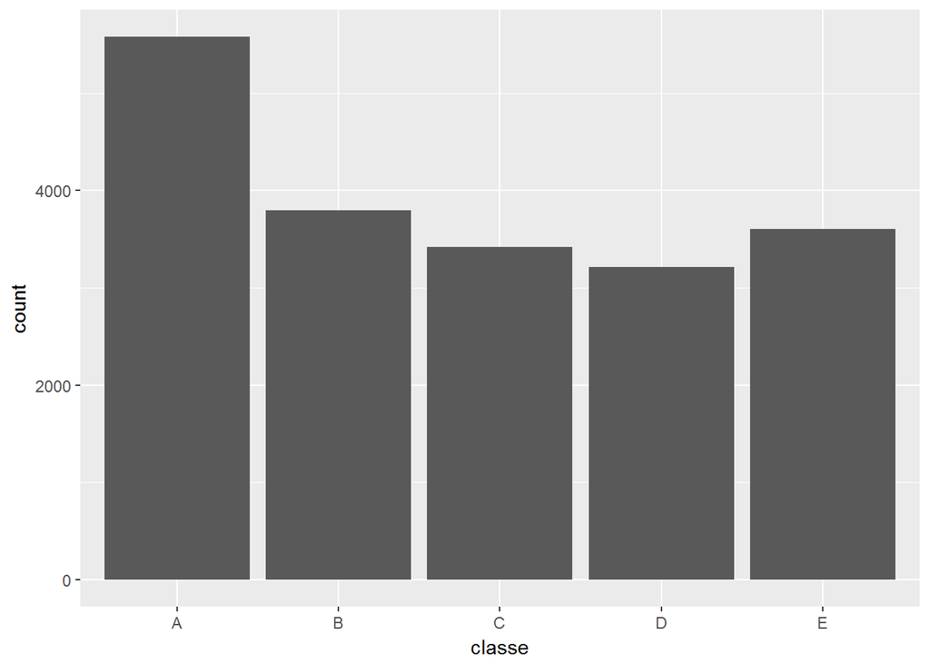

```r
ggplot(data=train_csv, aes(classe)) + geom_bar()
```

We then split the training data in separate training and test set. The test data that was downloaded is for the final grading of the project but before that we need to test on our models on a testing set that has outputs available.

```r
inTrain = createDataPartition(y=train_data$classe, p=0.7, list=FALSE)
training = train_data[inTrain,]
testing= train_data[-inTrain,]
```

```r
cindex <- findCorrelation(cor(train_data[, -53]), cutoff = 0.8)
colnames<- names(train_data[cindex])
colnames
```

```
##  [1] "accel_belt_z"     "roll_belt"        "accel_belt_y"
##  [4] "accel_dumbbell_z" "accel_belt_x"     "pitch_belt"
##  [7] "accel_arm_x"      "accel_dumbbell_x" "magnet_arm_y"
## [10] "gyros_forearm_y"  "gyros_dumbbell_x" "gyros_dumbbell_z"
## [13] "gyros_arm_x"
```

Some variables are correlated. Below is an example plot between accel_belt_z and roll_belt

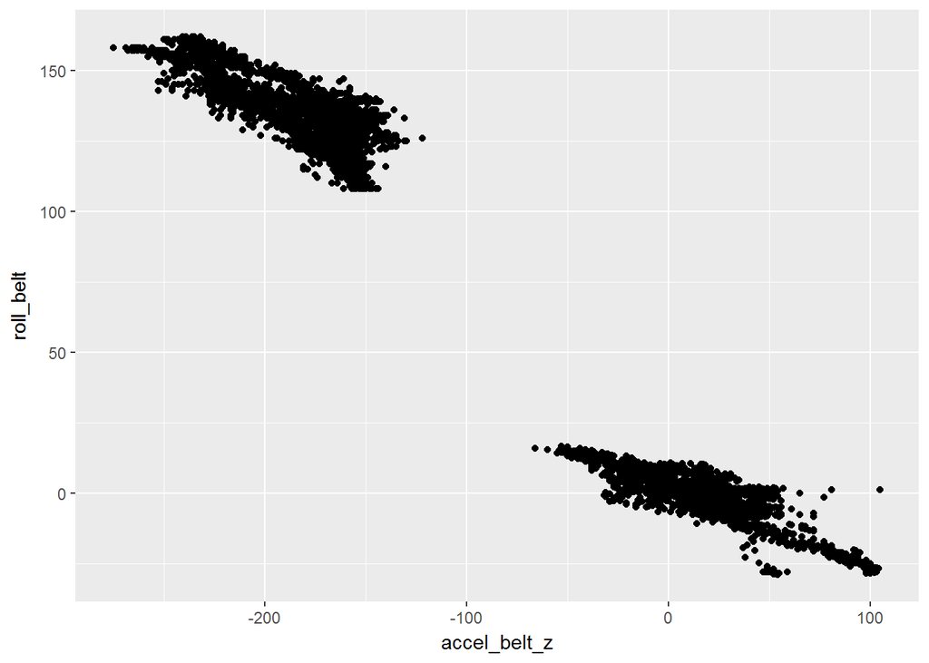

```r
ggplot(data=train_data, aes_string(colnames[1], colnames[2])) + geom_point()
```

Since some variables are correlated, we would also build models with PCA as pre-processing step.

# Models

## Setting control parametets.

Since this is large dataset, number of folds need not be large. Large number of folds would also increase the computation time for training. Here we have selected number of folds to be 5. Also we are using parallel backend.

```r
control <- trainControl(method="cv", number = 5, allowParallel=TRUE)
```

## Random Forest

```r
modFit_rf <- train(classe ~ ., data = training, method = "rf", trControl= control)
modFit_rf
```

```
## Random Forest
##
## 13737 samples
##    52 predictor
##     5 classes: 'A', 'B', 'C', 'D', 'E'
##
## No pre-processing
## Resampling: Cross-Validated (5 fold)
## Summary of sample sizes: 10990, 10987, 10990, 10991, 10990
## Resampling results across tuning parameters:
##
##   mtry  Accuracy   Kappa
##    2    0.9900274  0.9873841
##   27    0.9906834  0.9882140
##   52    0.9873343  0.9839774
##
## Accuracy was used to select the optimal model using  the largest value.
## The final value used for the model was mtry = 27.
```

```r
modFit_rf$finalModel
```

```
##
## Call:
##  randomForest(x = x, y = y, mtry = param$mtry)
##                Type of random forest: classification
##                      Number of trees: 500
## No. of variables tried at each split: 27
##
##         OOB estimate of  error rate: 0.68%
## Confusion matrix:
##      A    B    C    D    E  class.error
## A 3903    2    0    0    1 0.0007680492
## B   21 2632    5    0    0 0.0097817908
## C    1   13 2374    8    0 0.0091819699
## D    0    0   24 2227    1 0.0111012433
## E    0    3    4   10 2508 0.0067326733
```

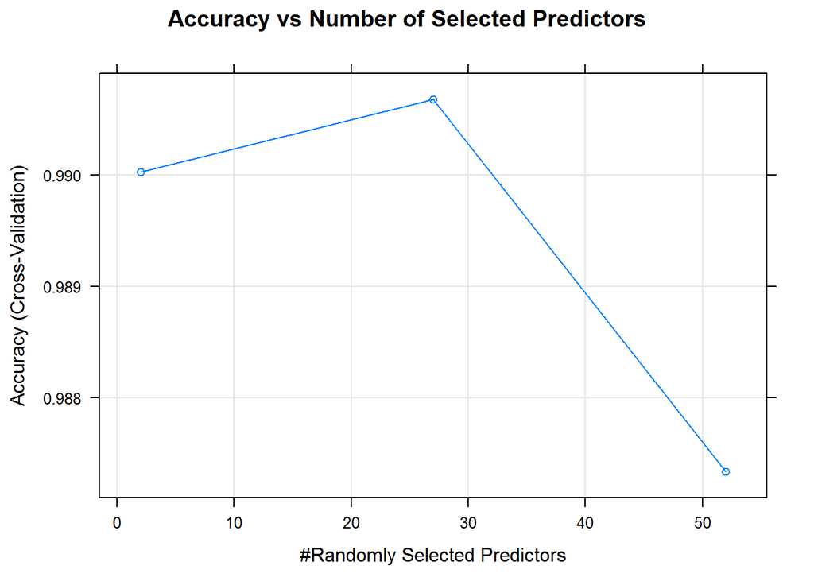

```r
plot(modFit_rf, main="Accuracy vs Number of Selected Predictors")
```

As you can see that OOB estimate is very low. Let us see that variable importance also.

```r
varImp(modFit_rf)
```

```
## rf variable importance
##
##   only 20 most important variables shown (out of 52)
##
##                      Overall
## roll_belt            100.000
## pitch_forearm         59.079
## yaw_belt              51.742
## pitch_belt            44.615
## magnet_dumbbell_z     41.071
## magnet_dumbbell_y     40.104
## roll_forearm          40.033
## accel_dumbbell_y      21.321
## magnet_dumbbell_x     17.347
## accel_forearm_x       17.308
## roll_dumbbell         16.412
## magnet_belt_z         14.750
## accel_dumbbell_z      13.619
## total_accel_dumbbell  13.449
## magnet_forearm_z      13.253
## accel_belt_z          12.545
## magnet_belt_y         11.172
## gyros_belt_z           9.948
## yaw_arm                9.295
## magnet_belt_x          9.072
```

### Test set accuracy

The model is used to predict output of test set.

```r
predictions_rf <- predict(modFit_rf, testing)
cm_rf <- confusionMatrix(predictions_rf, testing$classe)
cm_rf
```

```
## Confusion Matrix and Statistics
##
##           Reference
## Prediction    A    B    C    D    E
##          A 1671    7    0    0    0
##          B    3 1129    3    1    0
##          C    0    3 1020    5    1
##          D    0    0    2  958    1
##          E    0    0    1    0 1080
##
## Overall Statistics
##
##                Accuracy : 0.9954
##                  95% CI : (0.9933, 0.997)
##     No Information Rate : 0.2845
##     P-Value [Acc > NIR] : < 2.2e-16
##
##                   Kappa : 0.9942
##  Mcnemar's Test P-Value : NA
##
## Statistics by Class:
##
##                      Class: A Class: B Class: C Class: D Class: E
## Sensitivity            0.9982   0.9912   0.9942   0.9938   0.9982
## Specificity            0.9983   0.9985   0.9981   0.9994   0.9998
## Pos Pred Value         0.9958   0.9938   0.9913   0.9969   0.9991
## Neg Pred Value         0.9993   0.9979   0.9988   0.9988   0.9996
## Prevalence             0.2845   0.1935   0.1743   0.1638   0.1839
## Detection Rate         0.2839   0.1918   0.1733   0.1628   0.1835
## Detection Prevalence   0.2851   0.1930   0.1749   0.1633   0.1837
## Balanced Accuracy      0.9983   0.9949   0.9961   0.9966   0.9990
```

```r
out_of_sample_error_rf <- 1 - cm_rf$overall[[1]]
out_of_sample_error_rf
```

```
## [1] 0.004587935
```

As we can see, out of sample error is just 0.0045879 which is very good.

## Random Forest with PCA

```r
modFit_pca_rf <- train(classe ~ ., data = training, method = "rf", preProcess = "pca", trControl= control)
stopCluster(cl)
modFit_pca_rf
```

```
## Random Forest
##
## 13737 samples
##    52 predictor
##     5 classes: 'A', 'B', 'C', 'D', 'E'
##
## Pre-processing: principal component signal extraction (52), centered
##  (52), scaled (52)
## Resampling: Cross-Validated (5 fold)
## Summary of sample sizes: 10990, 10990, 10990, 10989, 10989
## Resampling results across tuning parameters:
##
##   mtry  Accuracy   Kappa
##    2    0.9679696  0.9594767
##   27    0.9572681  0.9459545
##   52    0.9578507  0.9466902
##
## Accuracy was used to select the optimal model using  the largest value.
## The final value used for the model was mtry = 2.
```

```r
modFit_pca_rf$finalModel
```

```
##
## Call:
##  randomForest(x = x, y = y, mtry = param$mtry)
##                Type of random forest: classification
##                      Number of trees: 500
## No. of variables tried at each split: 2
##
##         OOB estimate of  error rate: 2.55%
## Confusion matrix:
##      A    B    C    D    E class.error
## A 3874   11   13    3    5 0.008192524
## B   53 2561   38    1    5 0.036493604
## C    8   44 2324   16    4 0.030050083
## D    8    2   88 2152    2 0.044404973
## E    0   13   20   16 2476 0.019405941
```

```r
modFit_pca_rf$preProcess
```

```
## Created from 13737 samples and 52 variables
##
## Pre-processing:
##   - centered (52)
##   - ignored (0)
##   - principal component signal extraction (52)
##   - scaled (52)
##
## PCA needed 25 components to capture 95 percent of the variance
```

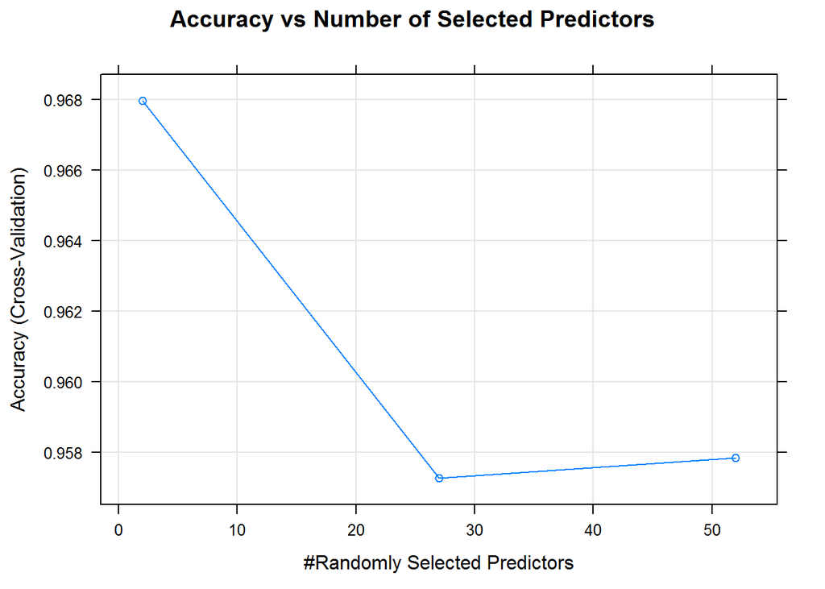

```r
plot(modFit_pca_rf, main="Accuracy vs Number of Selected Predictors")
```

```r
varImp(modFit_pca_rf)
```

```
## rf variable importance
##
##   only 20 most important variables shown (out of 52)
##
##                      Overall
## roll_belt            100.000
## pitch_forearm         60.209
## yaw_belt              52.340
## pitch_belt            44.084
## magnet_dumbbell_z     42.503
## magnet_dumbbell_y     41.730
## roll_forearm          40.751
## accel_dumbbell_y      21.891
## magnet_dumbbell_x     17.342
## roll_dumbbell         17.075
## accel_forearm_x       17.023
## magnet_belt_z         15.227
## magnet_forearm_z      14.136
## accel_dumbbell_z      13.944
## total_accel_dumbbell  13.839
## accel_belt_z          12.986
## magnet_belt_y         11.972
## gyros_belt_z          10.253
## yaw_arm               10.237
## magnet_belt_x          9.162
```

### Test set accuracy

The model is used to predict output of test set.

```r
predictions_pca_rf <- predict(modFit_pca_rf, testing)
cm_pca_rf <- confusionMatrix(predictions_pca_rf, testing$classe)
cm_pca_rf
```

```
## Confusion Matrix and Statistics
##
##           Reference
## Prediction    A    B    C    D    E
##          A 1672    8    0    0    0
##          B    2 1128    4    1    0
##          C    0    3 1019    5    1
##          D    0    0    2  958    3
##          E    0    0    1    0 1078
##
## Overall Statistics
##
##                Accuracy : 0.9949
##                  95% CI : (0.9927, 0.9966)
##     No Information Rate : 0.2845
##     P-Value [Acc > NIR] : < 2.2e-16
##
##                   Kappa : 0.9936
##  Mcnemar's Test P-Value : NA
##
## Statistics by Class:
##
##                      Class: A Class: B Class: C Class: D Class: E
## Sensitivity            0.9988   0.9903   0.9932   0.9938   0.9963
## Specificity            0.9981   0.9985   0.9981   0.9990   0.9998
## Pos Pred Value         0.9952   0.9938   0.9912   0.9948   0.9991
## Neg Pred Value         0.9995   0.9977   0.9986   0.9988   0.9992
## Prevalence             0.2845   0.1935   0.1743   0.1638   0.1839
## Detection Rate         0.2841   0.1917   0.1732   0.1628   0.1832
## Detection Prevalence   0.2855   0.1929   0.1747   0.1636   0.1833
## Balanced Accuracy      0.9985   0.9944   0.9957   0.9964   0.9980
```

```r
out_of_sample_error_pca_rf <- 1 - cm_pca_rf$overall[[1]]
```

As we can see, expected out of sample error is 0.0050977 which is very good and close to previous model. Also Sensitivity and Specificity is very close to previous model. But if we have to choose a single model, we would choose random forest without PCA as that gave slightly lower out of sample error.

## Predictions on 20 new test cases

```r
predict(modFit_rf, test_data)
```

```
##  [1] B A B A A E D B A A B C B A E E A B B B
## Levels: A B C D E
```

```r
predict(modFit_pca_rf, test_data)
```

```
##  [1] B A B A A E D B A A B C B A E E A B B B
## Levels: A B C D E
```

# Summary

The Weight Lifting Exercises Dataset had 19622 observations. Since the data is big, there was no problem in splitting it into training and test set. There were lot of missing values and those features that have more than 90% of missing values are removed. Random Forests were used as prediction model. Correlation analysis showed that some of the variable were correlated. So additional Random Forest model was built after doing pre-processing with PCA. The best results were given by Random Forest with an accuracy of over 99%. The models were also tried on 20 different test cases and they all gave same result for both models.